# Diff-in-Diff and RD Class

Maria Teresa Aguilar Rojas

The packages you will need for this exercise are the following:

```r
library(tidyverse)     # For ggplot, %>%, mutate, filter, group_by...
library(haven)         # For loading data from Stata
library(broom)         # For showing models as data frames
library(fixest)        # For fast, nice, fixed effects regression
library(modelsummary)  # For side-by-side regression tables
library(rdrobust)
library(rddensity)
library(modelsummary)
library(stargazer)

# This turns off this message that appears whenever you use summarize():
# `summarise()` ungrouping output (override with `.groups` argument)
options(dplyr.summarise.inform = FALSE)
```

## Difference-in-Differences Exercise

Based on 2004’s paper of Di Tella and Schargrodsky, we will analyze the effect of increased police presence on crime. Following a synagogue bombing in Buenos Aires, Argentina on July 18, 1994, extra municipal police were assigned to protect synagogues around the city. The increase of police patrols on some city blocks, but not others, means that there is arguably a treatment group and control group for increased police presence, which Di Tella and Schargrodsky used to measure the effect of extra police on car thefts.

The dataset (`MonthlyPanel.dta`) is a Stata data file nearly 10,000 observations. This data comes from [Di Tella and Schargrodsky’s data appendix available at their study’s *AER* webpage](https://www.aeaweb.org/articles?id=10.1257/000282804322970733). This is non-experimental data that includes counts of car thefts for every city block in Buenos Aires from April to December 1994. There are 12 variables:

- `observ` (we’ll rename to `block`): The ID number of the block
- `barrio`: The barrio (neighborhood) for the block
- `calle`: The street for the block
- `altura`: The street number
- `institu1` (we’ll rename to `same_block`): Indicator variable marking if there’s a Jewish institution on the block (1 if yes, 0 if no)
- `institu3`: Indicator variable marking if there’s a Jewish institution within one block (1 if yes, 0 if no)
- `distanci` (we’ll rename to `distance`): Distance to the nearest Jewish institution, measured in blocks
- `edpub`: Indicator variable marking if there’s an educational building or embassy on the block (1 if yes, 0 if no)
- `estserv`: Indicator variable marking if there’s a gas station on the block (1 if yes, 0 if no)
- `banco`: Indicator variable marking if there’s a bank on the block (1 if yes, 0 if no)
- `totrob` (we’ll rename to `car_theft`): Total number of car robberies
- `mes` (we’ll rename to `month`): Month

Before answering the questions, we will run the data and do a few transformations to some of the variables, as follows:

```r
setwd('/Users/emmabourdit/Desktop/Dauphine/R/TP2')

# Load terror data
crime <- read_dta("MonthlyPanel.dta") %>%
  # The attack happened on July 18. The authors omitted data from July 19-31, so
  # all July observations are from before the attack. Make a new indicator
  # variable `after` to mark if the row is from before or after the attack
  mutate(after = mes > 7) %>%
  # There are some weird months in the data like 73. Filter out anything > 12
  filter(mes <= 12) %>%
  # Rename some columns to be more readable
  rename(same_block = institu1,
         distance = distanci,
         car_theft = totrob,
         month = mes,
         block = observ) %>%
  # Create indicator variables for the distance of each block to a synagogue
  mutate(one_block_away = ifelse(distance == 1, 1, 0),
         two_blocks_away = ifelse(distance == 2, 1, 0),
         more_than_two_away = ifelse(distance > 2, 1, 0)) %>%
  # Make these factors/categories
  mutate(block = as.factor(block),
         month = as.factor(month),
         same_block_factor = as.factor(same_block))
```

**1.** Imagine you went out and collected data on the presence of police in each city, and the amount of crime in each city, and found a positive relationship. Does this mean police *cause* crime? Explain.

Solution: Probably there is a lot of crime in this city so there is a lot of police

**2.** How is this data suitable for a diff-in-diff design? What would we be comparing here? Be specific about the pre/post treatment/control groups.

Solution : - in the diff-in-diff, there is a group of control and a group of treatment. - there is an event that change the groups, a before and a after : the synagogue bombing of Buenos Aires, july 1994. - the two groups before the treatment don’t have to share the same characteristics but before the treatment there are in the same trend, and after the treatment one group follow the same trend when the other group change trend (Voir le cours y a graph qui montre bien) - treatment group : blocs with increase police - control group : blocs without - April to july 18th = pre-treatment period - july 19th = after-treatment period

**3.** Why does it help the researchers that the police were dispatched to certain blocks because of terrorist attacks?

Solution : This is a perfect exemple of diff-in-diff because we can compare blocks with police and blocks without police

**4.** What can we say about the parallel trends assumption in this case? Does it hold up? Solution : The parralel trend is the pre-treatment period.

Does police presence increase or decrease crime ? Variables that i am interested in : Variable in went to explain : car_theft (=vol de voiture, montre la criminalité) Independent variable : same_block Same_block est à 1 si y a + de police après le bombing (car y a une sinagogue dans le coin), si y a le même nombre de police avant et après est à 0 (car y a pas de sinagogue dans le coin). (block = quartier, pas immeuble) On veut un graph où sur les absisses on a time, sur les ordonnées car_theft

```r
crime_sum <- crime %>%
  group_by(month, same_block_factor) %>%
  summarise(avg_car_theft = mean(car_theft))

print(crime_sum)
```

| month | same_block_factor | avg_car_theft |
| --- | --- | --- |
| 4 | 0 | 0.10995232 |
| 4 | 1 | 0.12162162 |
| 5 | 0 | 0.09952324 |
| 5 | 1 | 0.08783784 |
| 6 | 0 | 0.07598331 |
| 6 | 1 | 0.12837838 |
| 7 | 0 | 0.04082241 |
| 7 | 1 | 0.02027027 |
| 8 | 0 | 0.11084625 |
| 8 | 1 | 0.04729730 |

[output cut: 8 more lines]

```r
NA
```

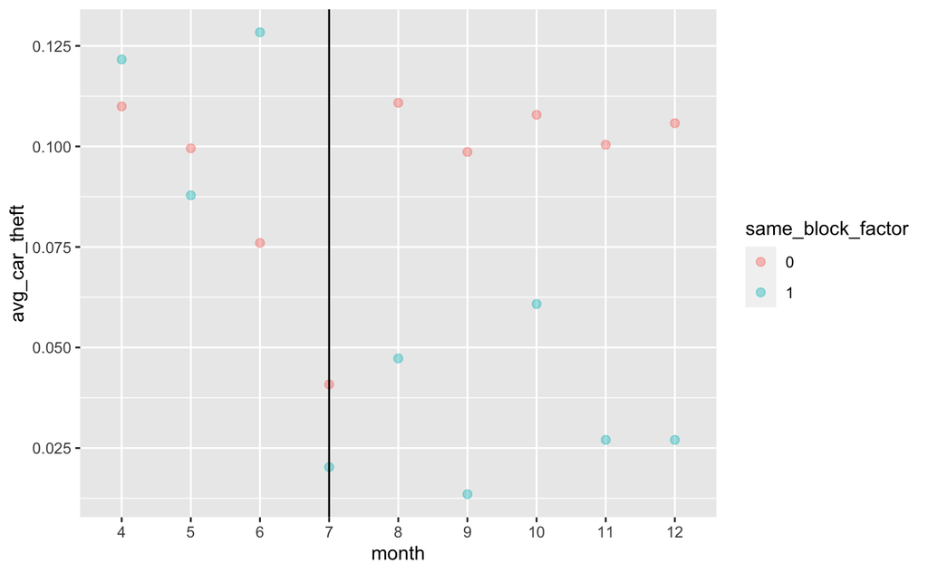

```r
# pour faire le graph :

ggplot(data = crime_sum, mapping = aes(x = month, y = avg_car_theft, color = same_block_factor)) + geom_point(size = 2, alpha = 0.4) + geom_vline(xintercept = "7")
```

```r
## permet juste de mettre les mois sur les absisses et avg_car_theft sur les ordonnées
```

**5.** Calculate “by-hand” the average number of car thefts in the treatment and control groups before and after the attack. (Hint: group by `same_block` and `after` and find the average of `car_theft`.) What is the diff-in-diff estimate

We do 2 levels of differences : difference pre and difference post. Block with and block without sinagogue.

same_block = 1 if synagogue 0 sinon after = 1 after july 19 0 if before

```r
#elle crée un table avec une variable after en FALSE ou TRUE
crime_diff <- crime %>%
  group_by(same_block, after) %>%
  summarise(avg_car_theft = mean(car_theft))
print(crime_diff)
```

| same_block | after | avg_car_theft |
| --- | --- | --- |
| 0 | FALSE | 0.08157032 |
| 0 | TRUE | 0.10470799 |
| 1 | FALSE | 0.08952703 |
| 1 | TRUE | 0.03513514 |

```r
# y a 4 cas (after et same_block a 1, after a 1 sameblock a 0, les deux à 0 ou after a 0 et sameblock a 1)
# we can see that before the treatment (=FALSE) the values are very similar. After (=TRUE) the police effect is huge.

#1ère ligne : the before_control variable
#3ème ligne : the before_treatment
#2ème ligne : the after_control
#4ème ligne : the after_treatment

#the difference between the control and the treatments
#the difference between before_treatment and after_treatment

#diff in diff option 1 :
#diff_before = before_treatment - before_control
#diff_after = after_treatment - after_control
#diff_before - diff_after
#diff in diff option 2 :
#diff_treat = after_treatment - before_treatment
#diff_control = after_control - before_control
#diff_treat - diff_control

before_treatment <- crime_diff %>%
  filter(after == 0, same_block == 1) %>%
  pull(avg_car_theft)

before_control <- crime_diff %>%
  filter(after == 0, same_block == 0) %>%
  pull(avg_car_theft)

after_treatment <- crime_diff %>%
  filter(after == 1, same_block == 1) %>%
  pull(avg_car_theft)

after_control <- crime_diff %>%
  filter(after == 1, same_block == 0) %>%
  pull(avg_car_theft)
```

**6.** Run a regression model to find the diff-in-diff estimate of the effect of the increased police presence (`after`) on car thefts (`car_theft`) (Hint: remember that you’ll be using an interaction term).

```r
#We will estimate the following model:
#car_theft=α+β after+γ same_block+δ (after×same_block)+ϵ
# (after×same_block) --> cest le treatment effect. Interraction between the block variable and the after variable
m1 <- lm(car_theft ~ after + same_block + after * same_block, data = crime)
summary(m1)
```

```
Call:
lm(formula = car_theft ~ after + same_block + after * same_block,
    data = crime)

Residuals:
     Min       1Q   Median       3Q      Max
-0.10471 -0.10471 -0.08157 -0.08157  2.39529

Coefficients:
                      Estimate Std. Error t value Pr(>|t|)
(Intercept)           0.081570   0.004171  19.557  < 2e-16 ***
afterTRUE             0.023138   0.005596   4.135 3.59e-05 ***
same_block            0.007957   0.020295   0.392  0.69503
afterTRUE:same_block -0.077530   0.027229  -2.847  0.00442 **
---
Signif. codes:  0 ‘***’ 0.001 ‘**’ 0.01 ‘*’ 0.05 ‘.’ 0.1 ‘ ’ 1

Residual standard error: 0.2416 on 7880 degrees of freedom
Multiple R-squared:  0.00354,   Adjusted R-squared:  0.003161
F-statistic: 9.333 on 3 and 7880 DF,  p-value: 3.721e-06
```

**7.** Compare the results “by hand” and those with the OLS regression. Explain the advantages of using the regression.

## Regression discontinuity design

To do a RDD, we will develop the following steps:

### Step 1: Determine if process of assigning treatment is rule-based

### Step 2: Determine if the design is fuzzy or sharp

### Step 3: Check for discontinuity in running variable around cutpoint

### Step 4: Check for discontinuity in outcome across running variable

### Step 5: Measure the size of the effect